# UdeSA - Clase 4

## 2. Explorando los datos de un shapefile

Filtremos solo los departamentos de la Provincia de Buenos Aires

```r
departamentos_pba <- departamentos %>%
  filter(provincia == "Buenos Aires") %>%
  mutate(personas = personas %>% as.character() %>% as.numeric())
```

Volvamos a graficar y, de yapa, coloreemos en base a la población.

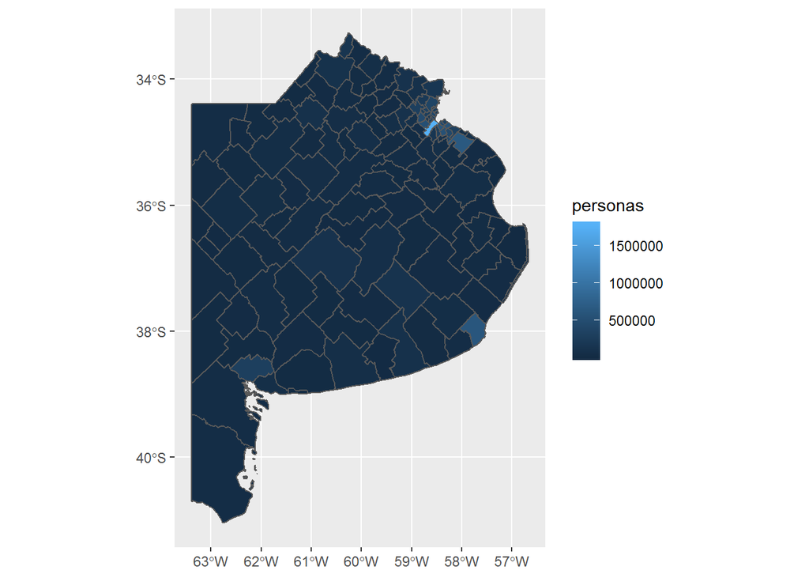

```r
ggplot() +
  geom_sf(data = departamentos_pba,
          aes(fill = personas))
```

Cuando vemos el mapa, nos damos cuenta que La Matanza es un outlier en la población del resto de la provincia. Esto lo podemos ver en el siguiente gráfico.

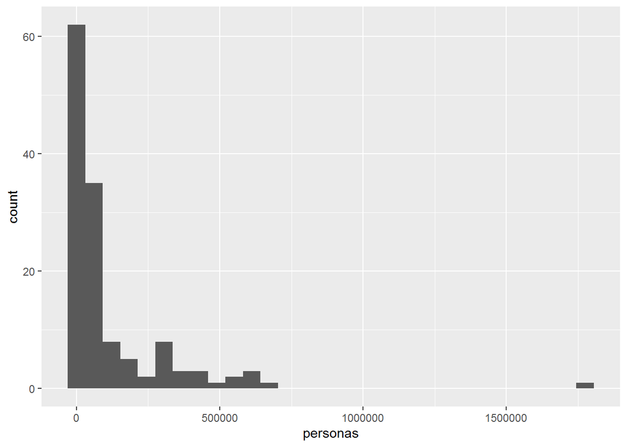

```r
ggplot() +
  geom_histogram(data = departamentos_pba,
                 aes(x = personas))
```

Por lo tanto, a fines puramente didácticas, hagamos el ejercicio de filtrarla momentaneamente. Y de yapa graficamos sacándole los bordes grises.

```r
departamentos_pba_sin_LM <- departamentos_pba %>%
  filter(personas < 1000000)
```

Ouala!

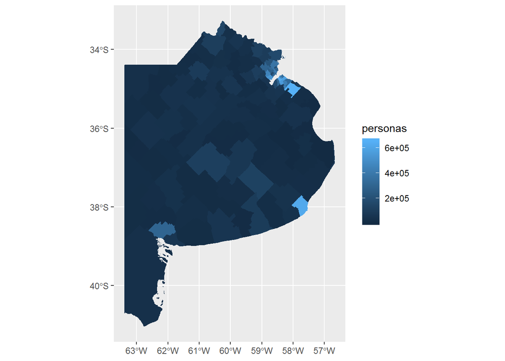

```r
ggplot() +
  geom_sf(data = departamentos_pba_sin_LM,
          aes(fill = personas),
          color = NA)
```

## 3. Haciendo operaciones

En la [clase anterior](https://lautarocantar.github.io/curso_udesa/clase03/) habíamos trabajado con los datos de las escuelas de la Provincia de Buenos Aires y habíamos armado un dataset llamado `escuelas_pba_2`. Abramos ese documento

```r
escuelas_pba_2 <- read_excel("escuelas_pba_2.xlsx")
```

Y ahora lo unimos a nuestro dataset `departamentos_pba`

```r
departamentos_pba <- departamentos_pba %>%
  left_join(escuelas_pba_2, by = c("link" = "codigo_indec"))
```

Veamos el ratio de escuelas por poblacion

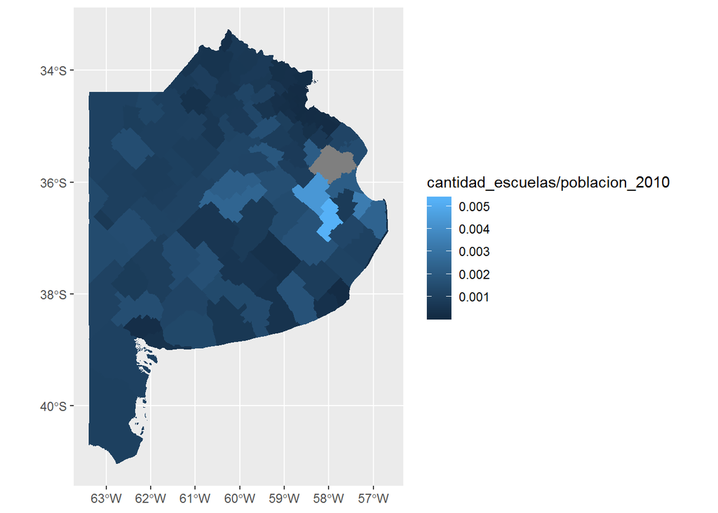

```r
ggplot() +
  geom_sf(data = departamentos_pba,
          aes(fill = cantidad_escuelas/poblacion_2010),
          color = NA)
```

## 4. Ejemplo: Olavarria

Ahora quiero unir dos datasets

```r
olavarria_escuelas <- escuelas %>%
   filter(provincia == "Buenos Aires") %>%
  mutate(codigo_indec = paste0("0", str_extract(cod_loc, "[0-9]{4}"))) %>%
  filter(codigo_indec == "06595")

olavarria_shp <- departamentos_pba %>% filter(link == "06595")
```

Y vamos a mapear los dos archivos todo juntos!!!

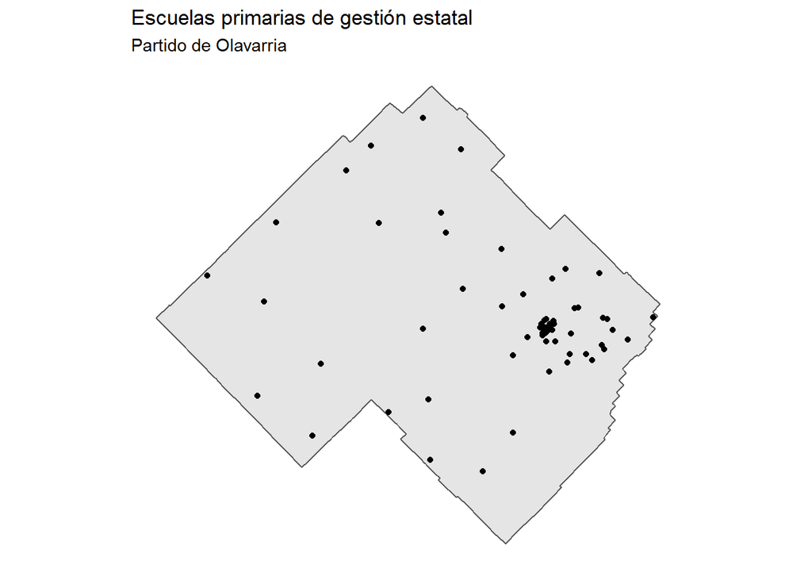

```r
ggplot() +
  geom_sf(data = olavarria_shp) +
  geom_point(data = olavarria_escuelas, aes(x = x, y = y)) +
  labs(title = "Escuelas primarias de gestión estatal",
       subtitle = "Partido de Olavarria") +
  theme(panel.background = element_blank(),
        axis.text.x = element_blank(),
        axis.text.y = element_blank(),
        axis.title = element_blank(),
        axis.ticks = element_blank())
```

## 5. Ahora interactivamente

```r
leaflet() %>%
  addTiles() %>%
  addProviderTiles("CartoDB.Positron") %>%
  addPolygons(data = olavarria_shp) %>%
  addMarkers(data = olavarria_escuelas,
             lng = ~x,
             lat = ~y,
             popup = ~as.character(nombre))
```

[interactive chart not shown]